# Cuatro entrenadores, un mismo club

De Santiago Solari, Fernando Ortiz, André Jardine a Guillermo Almada: qué idea de juego tuvo cada uno en el América, cómo la ajustó según el rival, el marcador y el minuto, y qué parte de sus resultados se explica por el juego y qué parte por la suerte.

395,167 posesiones de 1,798 partidos de Liga MX con eventos y 360 de Hudl StatsBomb, jul 2021 a oct 2026. Equipo CIDE OSOS · Hackathon ISAC 2026.

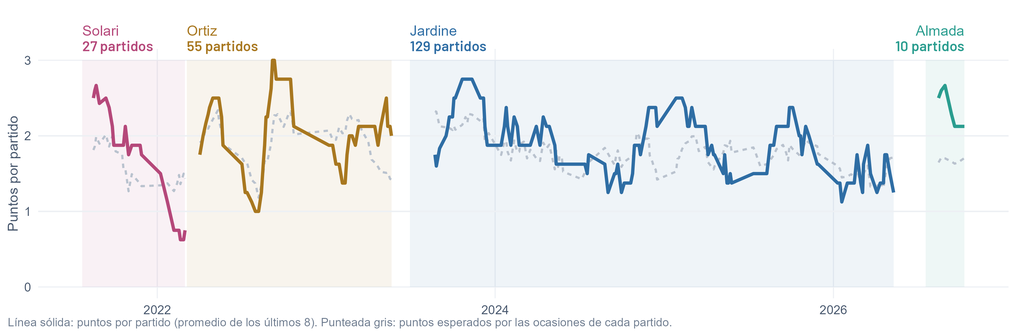

## Lo que hay que saber

- **Guillermo Almada es el que más puntos sacó por partido** (2.10). El plantel de más calidad individual lo tuvo Fernando Ortiz.
- **Las ocasiones explican casi todo, pero no todo.** Con las mismas ocasiones jugadas infinitas veces, Guillermo Almada habría sacado 0.37 puntos por partido menos de los que sacó; a Santiago Solari le faltaron 0.02.
- **Cada entrenador deja una huella reconocible.** Viendo solo el estilo de un partido (no el resultado), un modelo adivina quién dirigía en 58% de los casos, contra 25% por azar (prueba de permutación: p = 0.005).
- **Lo que más cambia de un entrenador a otro es pases por posesión**: el entrenador explica 16% de las diferencias entre partidos. Le siguen saque largo del portero (%) y presiones por posesión rival.
- **Guillermo Almada, hoy:** posesiones con tiro por encima de la liga (más que el 99% de los clubes-torneo) y recuperaciones en campo rival por partido por encima de la liga (más que el 90% de los clubes-torneo).

## Cómo lo medimos

Antes de mirar un solo partido definimos qué es cada cosa que se cuenta. Así, una gráfica de presión y una de transiciones hablan del mismo objeto y se pueden comparar entre entrenadores.

**Posesión**

Tramo continuo en que un equipo controla el balón. Usamos el número de posesión de StatsBomb; el dueño es el equipo con más acciones con balón (pases, conducciones, tiros, regates).

**Inicio de la posesión**

*Recuperación* si el rival tenía el balón en juego y se lo quitamos; *desde el portero* si arranca en un saque de meta o con el balón en manos del portero; *balón parado* si viene de un córner o de un tiro libre o lateral en el último tercio; *reanudación* si es un tiro libre o lateral más atrás; *saque inicial* después de un gol. Por cómo StatsBomb corta las posesiones, casi todas las demás empiezan quitándole el balón al rival.

**Secuencia ofensiva y sus fases**

Cada posesión propia, de principio a fin. *Construcción*: empieza en nuestro tercio (x < 40 de 120). *Progresión*: llega al medio (x ≥ 40) y al último tercio (x ≥ 80). *Finalización*: termina en tiro.

**Transición ofensiva**

Posesión que empieza con una recuperación. Es *rápida* si llega al último tercio en 10 segundos o menos, o termina en tiro en 15 o menos.

**Transición defensiva**

Posesión del rival que empieza porque perdimos el balón en juego.

**Fase de presión**

Nuestras presiones durante una posesión del rival. Se resume con presiones por posesión rival, PPDA (pases que el rival da en su 60% de cancha por cada acción defensiva nuestra ahí) y la altura a la que recuperamos.

**Contrapresión eficaz**

Perder el balón en juego y recuperarlo en 5 segundos o menos.

### Supuestos

- La cancha mide 120 × 80 y cada equipo ataca hacia x = 120; los carriles izquierdo, central y derecho son tercios del ancho, vistos desde quien ataca.
- Medimos lo que genera el juego con xG sin penales.
- **Todo se compara contra lo que hace la liga en la misma situación.** Cuando un equipo va perdiendo, cualquiera arriesga más; lo que dice algo del entrenador es cuánto más o menos que el resto. Lo mismo con la localía, el nivel del rival y el minuto.
- Cada partido pesa igual en los promedios, y los intervalos salen de remuestrear partidos: con pocos partidos (un interinato), el intervalo es ancho y lo decimos.

### Alcance y límites

- Son eventos, no tracking: vemos dónde ocurre cada acción con balón, no los desmarques sin balón (salvo la foto 360 en jugadas a balón parado).
- Un entrenador hereda una plantilla y un calendario. Por eso al lado de cada resultado mostramos el nivel del plantel y el de los rivales.
- Describimos y explicamos el juego; la simulación de partidos sirve para separar juego de suerte, no para pronosticar.

En toda la liga, 46% de las posesiones empiezan con una recuperación, 25% con una reanudación (lateral o tiro libre fuera del último tercio), 16% con balón parado en ataque y 11% desde el portero.

## Con qué jugó cada uno

Antes de juzgar la idea de juego hay que ver la mesa que le tocó a cada entrenador: cuánto duró, qué tan bueno era su plantel, qué tan difíciles fueron sus rivales y qué tanto le sonrió la suerte.

Santiago Solari

jul 2021 a mar 2022 · 27 partidos

Ganados, empatados, perdidos11–9–7

Puntos por partido1.56

Puntos esperados por partido1.58

xG a favor / en contra0.97 / 0.80

Calidad individual del plantel-0.14

Nivel del equipo (xG)83

Nivel medio del rival69

Fernando Ortiz

mar 2022 a may 2023 · 55 partidos

Ganados, empatados, perdidos32–14–9

Puntos por partido2.00

Puntos esperados por partido1.86

xG a favor / en contra1.57 / 0.85

Calidad individual del plantel+0.09

Nivel del equipo (xG)87

Nivel medio del rival69

Partidos de liguilla38

André Jardine

jul 2023 a may 2026 · 129 partidos

Ganados, empatados, perdidos69–35–25

Puntos por partido1.88

Puntos esperados por partido1.79

xG a favor / en contra1.40 / 0.86

Calidad individual del plantel+0.07

Nivel del equipo (xG)83

Nivel medio del rival71

Guillermo Almada

jul 2026 a oct 2026 · 10 partidos

Ganados, empatados, perdidos6–3–1

Puntos por partido2.10

Puntos esperados por partido1.73

xG a favor / en contra1.54 / 1.25

Calidad individual del plantel+0.04

Nivel del equipo (xG)78

Nivel medio del rival68

Diego Chávez dirigió 2 partidos (ene 2025): con tan pocos partidos no alcanza para hablar de una idea de juego, así que no se analiza aparte.

Calidad individual del plantel: índice medio de sus jugadores (z fiable de CIDE OSOS, ponderado por minutos); como el índice ya descuenta el nivel del equipo, mide a la plantilla y no el resultado del entrenador. Nivel del equipo y del rival: diferencia de xG sin penales por partido en el torneo, en una escala con media 70 y 10 puntos por desviación estándar. Puntos esperados: los que daban las ocasiones de cada partido (ver abajo).

### ¿Juego o suerte? Cada torneo repetido 10,000 veces

Cada tiro entra con una probabilidad igual a su xG. Si repetimos cada partido con las mismas ocasiones, sale la probabilidad de ganar, empatar o perder; si repetimos el torneo entero, sale el rango de puntos que el juego merecía. La barra gris va del 10% al 90% de esas repeticiones; el círculo blanco es el valor típico y el punto de color, lo que pasó.

[interactive chart not shown]

Sacó más puntos de los que merecía su juego (por encima del 90% de las repeticiones) en Apertura 2022 con Fernando Ortiz.

## La huella de cada entrenador

Cada punto es el promedio de un entrenador en sus partidos, medido en desviaciones frente a todos los clubes-torneo de la liga: 0 es lo normal en la Liga MX; +1, más que unos cinco de cada seis equipos.

[interactive chart not shown]

La línea alrededor de cada punto es su intervalo del 95% (remuestreo de partidos). Si cruza el 0, ese rasgo no se distingue del promedio de la liga. Pasa el cursor para ver el valor y el percentil.

**Santiago Solari**: rival al último tercio por debajo de la liga (menos que el 98% de los clubes-torneo); presiones por posesión rival por debajo de la liga (menos que el 94% de los clubes-torneo) y xG concedido en transición por partido por debajo de la liga (menos que el 92% de los clubes-torneo).

**Fernando Ortiz**: posesiones al último tercio por encima de la liga (más que el 97% de los clubes-torneo); posesiones con tiro por encima de la liga (más que el 94% de los clubes-torneo) y xG concedido en transición por partido por debajo de la liga (menos que el 89% de los clubes-torneo).

**André Jardine**: pases por posesión por encima de la liga (más que el 94% de los clubes-torneo); posesiones al último tercio por encima de la liga (más que el 86% de los clubes-torneo) y xG concedido en transición por partido por debajo de la liga (menos que el 89% de los clubes-torneo).

**Guillermo Almada**: posesiones con tiro por encima de la liga (más que el 99% de los clubes-torneo); recuperaciones en campo rival por partido por encima de la liga (más que el 90% de los clubes-torneo) y posesión por encima de la liga (más que el 96% de los clubes-torneo).

### ¿Se le reconoce por cómo juega su equipo?

Le dimos a un modelo (análisis discriminante lineal) los 18 indicadores de estilo de cada partido, sin el resultado ni la fecha, y le pedimos adivinar quién dirigía. Cada partido se adivina con un modelo entrenado sin él. Acertó en 58% de los casos, en promedio por entrenador; al azar se acertaría en 25%. Si se revuelven al azar los nombres de los entrenadores (200 veces), un acierto así o mejor aparece en 0.5% de los intentos.

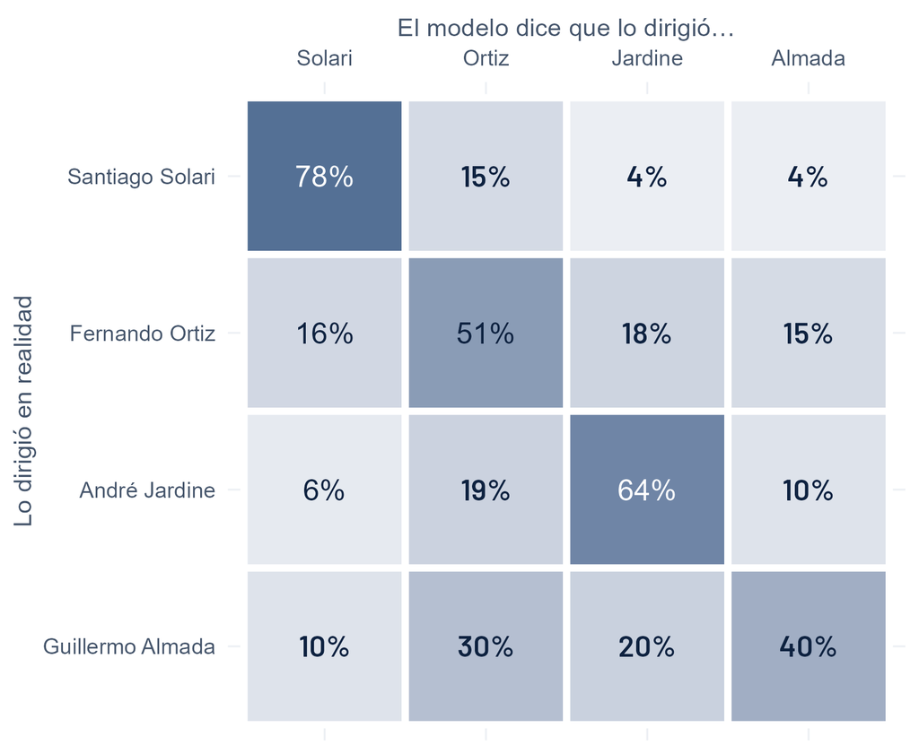

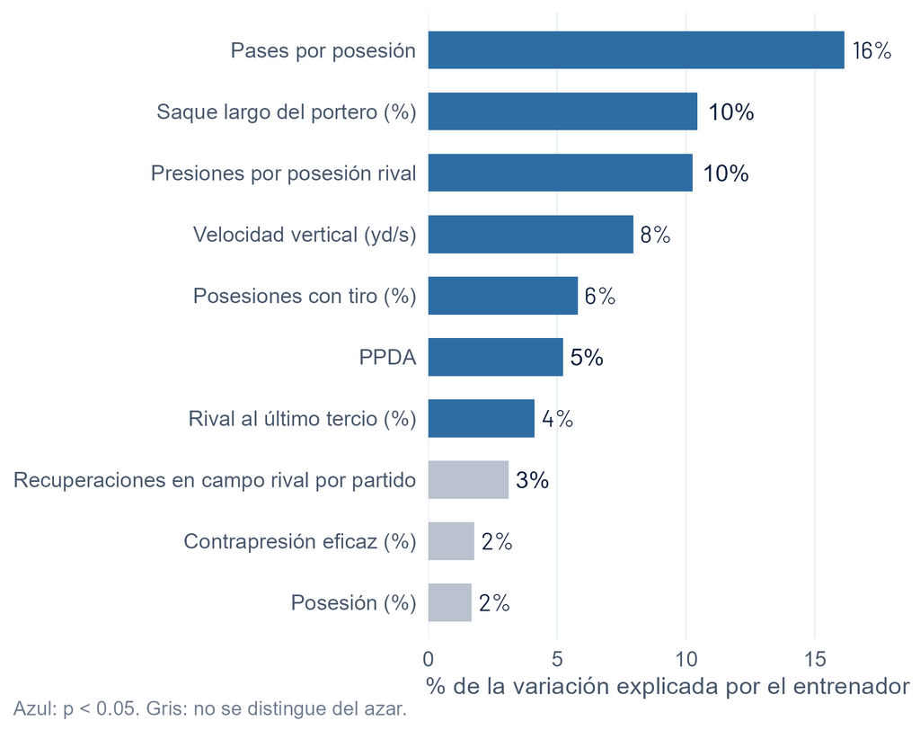

Izquierda: de los partidos que dirigió cada uno, a quién se los atribuye el modelo. La diagonal son los aciertos. Derecha: qué tanto de la variación de cada indicador entre partidos del América se explica por quién era el entrenador.

## Cómo atacaba

El América con Santiago Solari llevó 51% de sus posesiones al último tercio y terminó en tiro 11%; con Fernando Ortiz llevó 55% de sus posesiones al último tercio y terminó en tiro 14%; con André Jardine llevó 53% de sus posesiones al último tercio y terminó en tiro 12%; con Guillermo Almada llevó 54% de sus posesiones al último tercio y terminó en tiro 16%. En la liga, 48% y 11%.

### Posesión contra verticalidad

Cada punto gris es un club en un torneo; los de color, el América con cada entrenador. Hacia la derecha, más tiempo con el balón; hacia arriba, más yardas ganadas por segundo cuando avanza.

[interactive chart not shown]

### Por dónde entra al último tercio

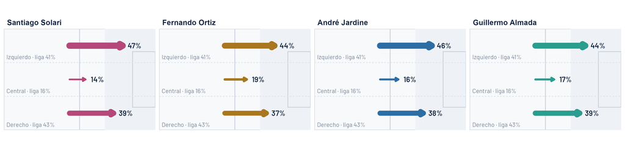

Porcentaje de las entradas al último tercio por cada carril, visto desde quien ataca (el arco rival está a la derecha). Debajo de cada carril, el promedio de la liga.

### Construcción y finalización

| Indicador | Santiago Solari | Fernando Ortiz | André Jardine | Guillermo Almada | Liga |
| --- | --- | --- | --- | --- | --- |
| Salida limpia (%) | 64.1 | 67.3 | 67.5 | 66.3 | 64.2 |
| Saque largo del portero (%) | 57.5 | 62.0 | 44.6 | 44.1 | 49.9 |
| Pases por posesión | 3.06 | 3.78 | 4.33 | 3.72 | 3.30 |
| Velocidad vertical (yd/s) | 4.33 | 3.98 | 3.75 | 3.74 | 4.12 |
| Posesiones al último tercio (%) | 51.3 | 55.2 | 52.9 | 54.2 | 48.5 |
| Posesiones con tiro (%) | 11.2 | 13.9 | 12.2 | 15.8 | 11.3 |
| xG cada 100 posesiones | 0.90 | 1.48 | 1.36 | 1.37 | 1.05 |
| xG en transición (%) | 41.8 | 42.7 | 44.9 | 37.6 | 42.4 |
| Transiciones rápidas por partido | 11.7 | 13.0 | 12.9 | 13.2 | 12.3 |

## Cómo defendía

El América con Santiago Solari recuperaba a una altura de 43 y concedía 0.8 xG cada 100 posesiones rivales; con Fernando Ortiz recuperaba a una altura de 42 y concedía 0.8 xG cada 100 posesiones rivales; con André Jardine recuperaba a una altura de 42 y concedía 0.9 xG cada 100 posesiones rivales; con Guillermo Almada recuperaba a una altura de 44 y concedía 1.1 xG cada 100 posesiones rivales. En la liga, el promedio es 42 y 1.1.

### Intensidad contra altura de la presión

[interactive chart not shown]

El eje horizontal va al revés: a la derecha, más presión.

| Indicador | Santiago Solari | Fernando Ortiz | André Jardine | Guillermo Almada | Liga |
| --- | --- | --- | --- | --- | --- |
| PPDA | 2.63 | 2.49 | 2.88 | 2.89 | 2.78 |
| Presiones por posesión rival | 1.05 | 1.26 | 1.35 | 1.06 | 1.27 |
| Altura de recuperación (x) | 42.8 | 41.9 | 42.3 | 44.0 | 42.0 |
| Recuperaciones en campo rival por partido | 11.4 | 12.3 | 11.9 | 15.3 | 12.2 |
| Contrapresión eficaz (%) | 14.1 | 12.4 | 13.9 | 12.3 | 13.4 |
| Altura del bloque (x) | 54.5 | 53.8 | 53.3 | 52.8 | 51.7 |
| Rival al último tercio (%) | 40.5 | 45.5 | 46.4 | 44.7 | 48.8 |
| xG concedido cada 100 posesiones rivales | 0.76 | 0.81 | 0.86 | 1.11 | 1.07 |
| xG concedido en transición por partido | 0.35 | 0.36 | 0.36 | 0.49 | 0.51 |

## Cómo ajustaba según el partido

Un entrenador se conoce por lo que cambia cuando el partido cambia. Cada punto es cuánto se movió el América en esa situación **por encima o por debajo de lo que se mueve cualquier equipo de la liga** en la misma situación. Si la línea cruza el 0, ese ajuste es el mismo que haría cualquiera.

### Según el marcador

Comparado con cuando va empatado.

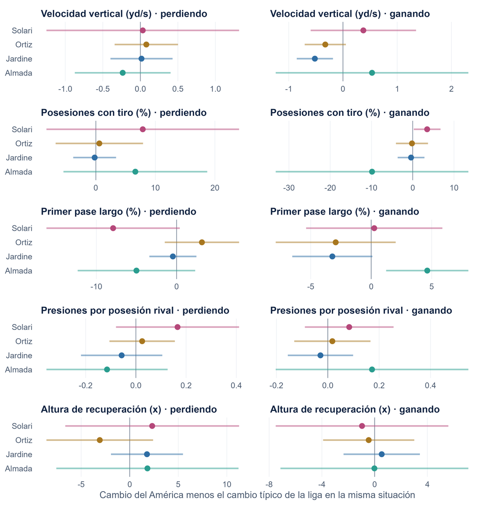

### En casa

Comparado con cuando juega de visita.

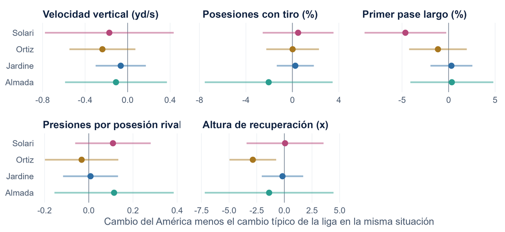

### Contra el 20% más fuerte de la liga

Comparado con el resto de los rivales.

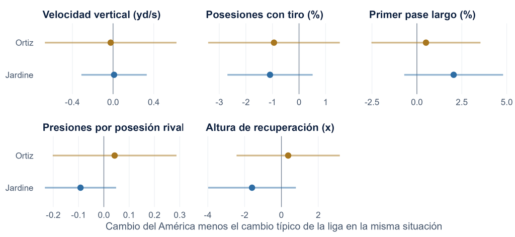

### En el último cuarto de hora

Del minuto 75 en adelante, comparado con los primeros 30 minutos.

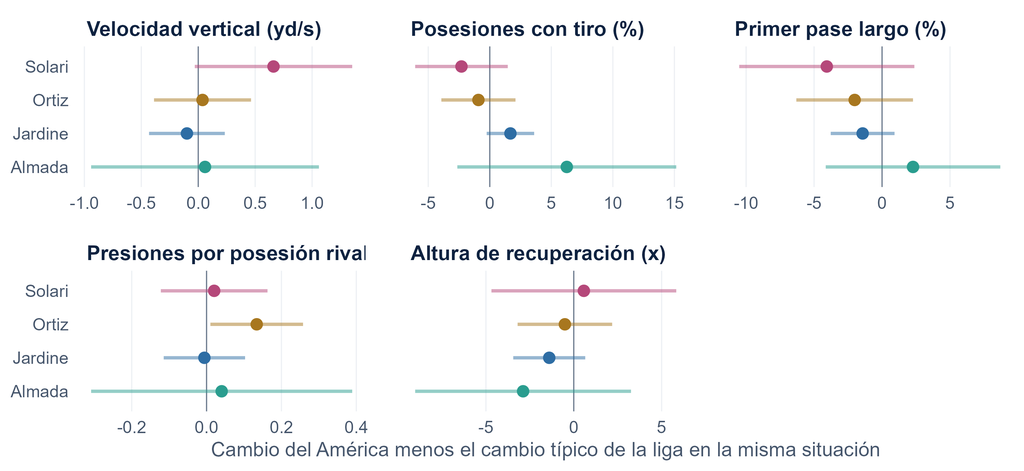

**Santiago Solari**. Marcador (ganando): posesiones con tiro cambia -0.37 con el América y -3.87 en la liga. Localía (local): primer pase largo cambia -6.07 con el América y -1.43 en la liga.

**Fernando Ortiz**. Localía (local): altura de recuperación cambia -0.58 con el América y +2.27 en la liga. Minuto (75’+): presiones por posesión rival cambia -0.09 con el América y -0.22 en la liga.

**André Jardine**. Marcador (ganando): velocidad vertical cambia +0.38 con el América y +0.90 en la liga.

**Guillermo Almada**. Marcador (ganando): primer pase largo cambia +13.82 con el América y +9.18 en la liga.

## Cómo cambió con el tiempo

La banda gris es la mitad central de la liga en cada torneo; la línea punteada, su mediana. Elige el indicador en el menú.

[interactive chart not shown]

## Con qué jugadores

| Entrenador | Partidos | Jugadores usados | Edad media (por minutos) | Titulares que cambian entre partidos | % de minutos de los 14 más usados | % de minutos de jugadores heredados | Minuto del primer cambio | Impacto de sus cambios (OBV) |
| --- | --- | --- | --- | --- | --- | --- | --- | --- |
| Santiago Solari | 27 | 32 | 27.8 | 3.7 | 77 | — | 57 | -0.29 ± 1.37 |
| Fernando Ortiz | 55 | 38 | 28.0 | 2.4 | 76 | 84 | 62 | -0.14 ± 0.93 |
| André Jardine | 129 | 57 | 27.8 | 3.6 | 69 | 58 | 59 | +0.60 ± 0.64 |
| Guillermo Almada | 10 | 31 | 27.5 | 5.6 | 76 | 86 | 61 | +0.90 ± 2.18 |

Heredados: jugadores que ya habían jugado con el club antes de que llegara ese entrenador (no se calcula para el primero de la base). Impacto de los cambios: diferencia de OBV del equipo contra el rival por 90 minutos en los 15 minutos después del cambio menos los 15 antes, descontando lo que pasa en promedio en la liga en ese minuto y con ese marcador; con su intervalo del 95%.

### Dónde están los minutos

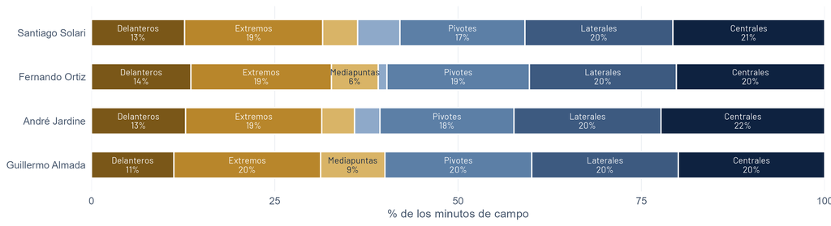

**Formaciones más usadas.** Santiago Solari: 4-2-3-1 (47%), 4-4-2 (21%), 4-1-4-1 (11%). Fernando Ortiz: 4-2-3-1 (58%), 4-4-2 (32%), 4-3-3 (3%). André Jardine: 4-2-3-1 (40%), 4-4-2 (22%), 3-4-3 (11%). Guillermo Almada: 4-2-3-1 (88%), 4-4-2 (12%), 4-4-1-1 (1%).

### ¿Mejoró a sus jugadores?

Tomamos a cada jugador que siguió en el club de un torneo al siguiente (con 450 minutos o más en los dos) y medimos cuánto cambió su índice. No basta con el cambio bruto: quien tuvo un torneo muy bueno suele bajar en el siguiente, quien tuvo uno malo suele subir, y los jóvenes mejoran con la edad. Por eso comparamos el cambio con lo que le pasa en promedio a un jugador de la liga con su mismo nivel previo, edad y posición (1,755 pares de torneos). Lo que queda es la mejora que se le puede atribuir al entorno del club: el entrenador y su cuerpo técnico.

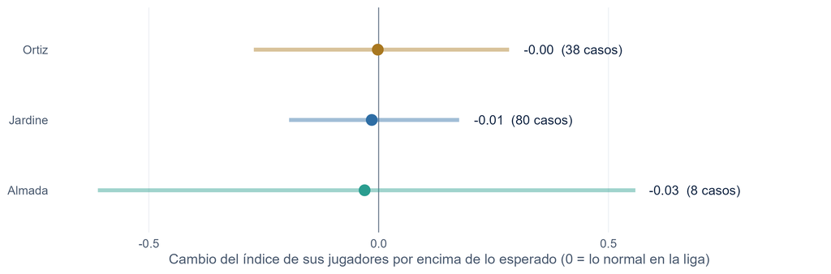

**Fernando Ortiz**: sus jugadores cambiaron lo normal: no se distingue de la liga (-0.00; mejor que el 49% de los clubes-torneo). **André Jardine**: sus jugadores cambiaron lo normal: no se distingue de la liga (-0.01; mejor que el 47% de los clubes-torneo). **Guillermo Almada**: sus jugadores cambiaron lo normal: no se distingue de la liga (-0.03; mejor que el 45% de los clubes-torneo).

Santiago Solari: no hay un torneo completo suyo con el torneo anterior en la base para comparar.

Los tres jugadores que más crecieron con cada uno:

| Entrenador | Jugador | Posición | Edad | De | A | Mejora sobre lo esperado |
| --- | --- | --- | --- | --- | --- | --- |
| Fernando Ortiz | Pedro Jesús Aquino Sánchez | Pivote | 28 | Apertura 2022 (-0.05) | Clausura 2023 (+1.46) | +1.49 |
| Fernando Ortiz | Álvaro Fidalgo Fernández | Pivote | 25 | Clausura 2022 (+0.52) | Apertura 2022 (+1.48) | +1.28 |
| Fernando Ortiz | Diego Alfonso Valdés Contreras | Mediapunta | 29 | Apertura 2022 (-0.02) | Clausura 2023 (+1.39) | +1.21 |
| André Jardine | Dagoberto Espinoza Acosta | Lateral | 21 | Apertura 2024 (-1.26) | Clausura 2025 (+1.49) | +2.02 |
| André Jardine | Israel Reyes Romero | Pivote | 26 | Apertura 2025 (-0.02) | Clausura 2026 (+1.86) | +1.89 |
| André Jardine | Israel Reyes Romero | Central | 25 | Apertura 2024 (+0.22) | Clausura 2025 (+1.65) | +1.54 |
| Guillermo Almada | Paul Brian Rodríguez Bravo | Extremo | 26 | Clausura 2026 (+0.70) | Apertura 2026 (+1.92) | +1.48 |
| Guillermo Almada | Erick Daniel Sánchez Ocegueda | Pivote | 27 | Clausura 2026 (-0.55) | Apertura 2026 (+0.39) | +0.65 |
| Guillermo Almada | Miguel Ángel Vázquez García | Central | 22 | Clausura 2026 (-1.20) | Apertura 2026 (-0.20) | +0.34 |

### Los fichajes de cada etapa

[interactive chart not shown]

Cada punto es un jugador que llegó al club durante esa etapa y jugó 300+ minutos en su primer torneo. Sobre la diagonal, rindió más con el América que en su club anterior; el tamaño crece con sus minutos. El nivel es el índice de CIDE OSOS: rendimiento por 90 minutos frente a los de su posición, descontando el contexto de su equipo y contraído hacia 0 cuando tiene pocos minutos.

Llegadas por etapa. Fernando Ortiz: 17 (2 por encima del promedio de su posición en su primer torneo; 0 con menos de 450 minutos). André Jardine: 37 (5 por encima del promedio de su posición en su primer torneo; 0 con menos de 450 minutos). Guillermo Almada: 9 (0 por encima del promedio de su posición en su primer torneo; 0 con menos de 450 minutos).

## Balón parado

Índice de xG por saque: xG sin penales de todos los tiros que salen de la jugada, dividido entre el número de saques, con 100 = promedio de la liga. A favor, más es mejor; en contra, menos es mejor.

| Lado | Tipo | Santiago Solari | Fernando Ortiz | André Jardine | Guillermo Almada |
| --- | --- | --- | --- | --- | --- |
| A favor | Córner | 95 (2 goles, 4.7 por partido) | 93 (7 goles, 5.8 por partido) | 99 (21 goles, 5.3 por partido) | 162 (4 goles, 6.9 por partido) |
| A favor | Lateral en último tercio | 58 (1 goles, 8.6 por partido) | 92 (7 goles, 7.8 por partido) | 121 (13 goles, 7.0 por partido) | 141 (1 goles, 6.8 por partido) |
| A favor | Tiro libre directo | 85 (0 goles, 1.2 por partido) | 118 (8 goles, 1.6 por partido) | 121 (4 goles, 1.2 por partido) | 99 (2 goles, 1.2 por partido) |
| A favor | Tiro libre indirecto | 89 (2 goles, 6.4 por partido) | 124 (8 goles, 5.1 por partido) | 118 (13 goles, 4.8 por partido) | 101 (2 goles, 5.3 por partido) |
| En contra | Córner | 74 (4 goles, 4.2 por partido) | 94 (9 goles, 3.9 por partido) | 100 (18 goles, 4.6 por partido) | 101 (2 goles, 5.3 por partido) |
| En contra | Lateral en último tercio | 70 (2 goles, 7.1 por partido) | 69 (0 goles, 6.7 por partido) | 96 (3 goles, 6.6 por partido) | 135 (1 goles, 8.1 por partido) |
| En contra | Tiro libre directo | 81 (0 goles, 1.0 por partido) | 83 (1 goles, 1.1 por partido) | 76 (1 goles, 1.1 por partido) | 38 (0 goles, 1.0 por partido) |
| En contra | Tiro libre indirecto | 123 (3 goles, 5.1 por partido) | 98 (5 goles, 4.2 por partido) | 104 (8 goles, 3.4 por partido) | 11 (0 goles, 3.5 por partido) |

Ojo al leerlo: de un torneo al siguiente, el xG por córner de un club se repite poco (correlación 0.04 entre clubes). Con unos 80 córners por torneo, la diferencia entre etapas puede ser azar; el primer contacto y la organización se repiten más.

## Qué hacer con esto

Tablero para el cuerpo técnico de Guillermo Almada. El objetivo de cada indicador es el nivel del mejor cuarto de la liga (el 25% de clubes-torneo con mejor valor). Los que no se cumplen van primero, ordenados por qué tan lejos están de la meta en relación con la variación normal de la liga.

| Indicador | Fase | Actual | Objetivo | Estado | Qué mide |
| --- | --- | --- | --- | --- | --- |
| Contrapresión eficaz (%) | Transición | 12.3 | 14.4 | Por debajo | Pérdidas en juego recuperadas en 5 s o menos. |
| PPDA | Presión | 2.89 | 2.49 | Por debajo | Pases del rival en su 60% de cancha por acción defensiva propia ahí. Menos = presión más intensa. |
| xG en contra por partido | Resultado | 1.25 | 1.00 | Por debajo | xG sin penales del rival. |
| xG concedido cada 100 posesiones rivales | Defensa | 1.11 | 0.91 | Por debajo | xG sin penales del rival por cada 100 de sus posesiones. |
| xG concedido en transición por partido | Defensa | 0.49 | 0.41 | Por debajo | xG del rival en posesiones que empiezan tras una pérdida nuestra. |
| Transiciones rápidas por partido | Transición | 13.2 | 13.6 | Por debajo | Recuperaciones que llegan al último tercio en ≤10 s o terminan en tiro en ≤15 s. |
| Salida limpia (%) | Construcción | 66.3 | 66.5 | Por debajo | De las posesiones que empiezan en el tercio propio, % que llega al medio campo. |
| Rival al último tercio (%) | Defensa | 44.7 | 45.9 | Cumple | % de posesiones del rival que llegan a nuestro último tercio. |
| Field tilt (%) | Dominio | 59.8 | 55.5 | Cumple | % de los pases en el último tercio que son propios. |
| Posesiones al último tercio (%) | Progresión | 54.2 | 51.4 | Cumple | % de posesiones propias que llegan a x ≥ 80. |
| xG cada 100 posesiones | Finalización | 1.37 | 1.18 | Cumple | xG sin penales generado por cada 100 posesiones propias. |
| xG a favor por partido | Resultado | 1.54 | 1.30 | Cumple | xG sin penales. |
| Recuperaciones en campo rival por partido | Presión | 15.3 | 13.3 | Cumple | Recuperaciones con x ≥ 60. |
| Posesiones con tiro (%) | Finalización | 15.8 | 12.3 | Cumple | % de posesiones propias que terminan en tiro. |

Prioridades

- **Contrapresión eficaz (%)**: de 12.3 a 14.4. Pérdidas en juego recuperadas en 5 s o menos.
- **PPDA**: de 2.89 a 2.49. Pases del rival en su 60% de cancha por acción defensiva propia ahí. Menos = presión más intensa.
- **xG en contra por partido**: de 1.25 a 1.00. xG sin penales del rival.

### El perfil que le falta al plantel

Comparamos al mejor jugador del América en cada posición (temporada 2026/2027, 450+ minutos) con el mejor de un club típico de la liga. Las posiciones con más brecha son **interior y mediapunta**. Estos son los candidatos de la liga con mejor índice en esas posiciones, de 28 años o menos:

| Posición | Jugador | Club | Edad | Minutos | Índice (z fiable) |
| --- | --- | --- | --- | --- | --- |
| Mediapunta | Mathías Adrián Tomás Borges | Puebla | 26 | 440 | 0.14 |
| Mediapunta | Ían Jairo Misael Torres Ramírez | Juárez | 26 | 581 | 0.02 |
| Mediapunta | Mateo Agustín Coronel | Querétaro | 28 | 775 | -0.15 |
| Interior | Brian Gutierrez | Guadalajara | 23 | 569 | 0.35 |
| Interior | Gilberto Rafael Mora Zambrano | Tijuana | 18 | 527 | 0.22 |
| Interior | Ramón Rodríguez Jiménez | Juárez | 27 | 661 | 0.12 |
| Interior | Luka Romero Bezzana | Cruz Azul | 22 | 454 | 0.10 |
| Interior | Adalberto Eliécer Carrasquilla Alcázar | Pumas UNAM | 28 | 408 | 0.06 |

## Anexo: los modelos y sus límites

### El índice de jugadores

El nivel de los jugadores, el plantel y los fichajes sale del modelo de scouting de CIDE OSOS. Para cada jugador se mide su rendimiento por 90 minutos en 13 métricas agrupadas en cinco índices (ofensivo, creación, defensivo, progresión y consistencia), frente a los de su posición, descontando el nivel de su equipo y del rival, y contrayendo hacia 0 cuando tiene pocos minutos.

Probado contra 272 traspasos reales dentro de la liga: el índice antes del traspaso se correlaciona 0.28 [0.16, 0.39] con el rendimiento en el club nuevo; los minutos que jugaba antes, 0.04. En cada torneo el modelo solo vio partidos anteriores.

Es un rasgo estable: de un torneo al siguiente se repite con correlación 0.46; el OBV, 0.17.

### Qué tan estable es cada métrica de equipo

Correlación entre clubes de un torneo al siguiente. Cerca de 1, la métrica describe al club; cerca de 0, cambia por azar.

| Indicador | Correlación entre torneos | IC 95% |
| --- | --- | --- |
| Diferencia de xG por partido | 0.64 | [0.53, 0.72] |
| Field tilt | 0.68 | [0.58, 0.75] |
| PPDA | 0.42 | [0.27, 0.54] |
| Pases progresivos por partido | 0.68 | [0.58, 0.77] |
| Presiones en campo rival | 0.51 | [0.41, 0.61] |
| xG por córner a favor | 0.04 | [-0.12, 0.21] |
| xG por córner en contra | 0.16 | [-0.00, 0.30] |
| % primer contacto en córner a favor | 0.25 | [0.11, 0.38] |
| Impacto medio de los cambios del club | 0.06 | [-0.08, 0.19] |

### Datos y reproducibilidad

Datos de eventos y 360 de Hudl StatsBomb, Liga MX. El reporte muestra solo resultados agregados, no los datos. Todo se reproduce con el código del proyecto: `R/02_pipeline.R` → `R/03_validacion.R` → `R/04_tactico.R` → `R/05a_entrenadores.R` → `R/05_entrenadores.R` → este reporte. Entrenador de cada partido: lista de partidos de la API; en su defecto, `config/entrenadores_manual.csv`.

CIDE OSOS · Centro de Investigación y Docencia Económicas · Hackathon ISAC 2026, Club América.